# Changes in terrestrial ecosystem threat status

Authors

Maphale Monyeki

Andrew Skowno

Mthobisi Nzimande

Anisha Dayaram

Tammy Smith

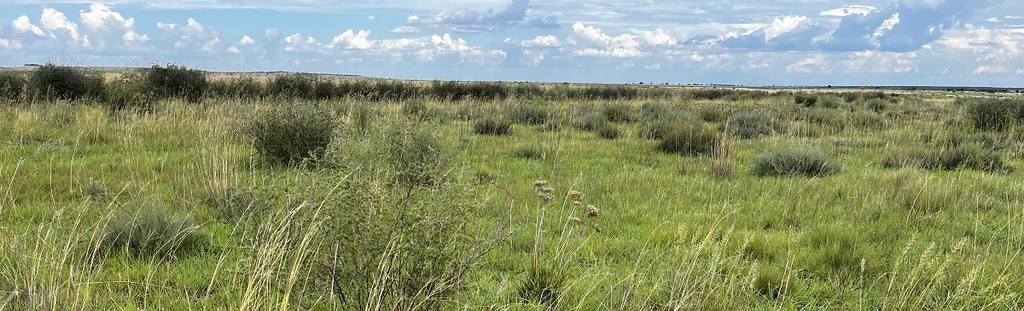

# Changes in terrestrial ecosystem threat status

How the threat status of South Africa's 463 terrestrial ecosystem types has shifted between the 2022 gazetted list and the NBA 2025 assessment

Vaalvet Sandy Grassland (© Philip Desmet)

463 Ecosystem types assessed

434 Unchanged since 2022

21 Uplisted since 2022

0 Downlisted

8 Newly delineated ecosystem types

81% of historical extent still natural

Maphale Monyeki<sup>1</sup> , Andrew Skowno<sup>2,3</sup> , Mthobisi Nzimande<sup>1</sup>, Anisha Dayaram<sup>1,4</sup> , Tammy Smith<sup>1</sup>

<sup>1</sup> South African National Biodiversity Institute (SANBI), <sup>2</sup> Group on Earth Observations (GEO), <sup>3</sup> University of Cape Town (UCT), <sup>4</sup> University of the Witwatersrand

Published: 30 September 2026

## Introduction

In 2025, the fourth iteration of the [National Biodiversity Assessment (NBA)](https://nba.sanbi.org.za/) was released, building on more than two decades of biodiversity assessments at a national scale. The NBA is a national monitoring and reporting tool that synthesises information on the state of biodiversity in South Africa using a suite of headline indicators, including the Red List of Ecosystems (RLE), also referred to as ecosystem threat status. This indicator also forms part of the growing toolbox of ecosystem indicators recognised within the Kunming-Montreal Global Biodiversity Framework of the Convention on Biological Diversity (CBD), to which South Africa is a signatory.

The ecosystem threat status indicator is one of the longest-standing indicators reported through the NBA. In the absence of a globally recognised standard for assessing ecosystem threat status, South Africa developed and applied its own national criteria. These criteria were first systematically applied to terrestrial ecosystems, with the findings reported in the [National Spatial Biodiversity Assessment (NSBA) 2004](https://bgis.sanbi.org/Projects/Detail/55). This national approach demonstrated the feasibility of assessing the threat status of broad ecological features such as ecosystems, despite their complex and dynamic nature.

Following this initial assessment, the national criteria were refined to improve the robustness and consistency of their application and expanded to incorporate additional criteria and data. These developments enabled more detailed and comprehensive assessments of ecosystem threat status, with the findings summarised in the NBA 2011 report. To strengthen the influence of these assessments on policy and decision-making, the 2011 list of threatened ecosystems was subsequently gazetted in 2011 under the [National Environmental Management: Biodiversity Act (NEMBA)](https://www.gov.za/documents/national-environmental-management-biodiversity-act-2011). Gazetting provided a formal legal basis for incorporating threatened ecosystems into higher-level legal, regulatory, and planning instruments, thereby supporting their conservation and management interventions.

Although South Africa has a long history of assessing ecosystem threat status, it subsequently adopted the International Union for Conservation of Nature (IUCN) RLE framework in 2018. The RLE framework provides a globally consistent approach for assessing the risk of ecosystem collapse. Its adoption has strengthened the consistent application of ecosystem threat assessments across South Africa’s diverse ecosystem realms and improved comparability among regions. It has also facilitated the integration of ecosystem threat status into global biodiversity monitoring and reporting frameworks and contributed to efforts to develop a comprehensive global list of threatened ecosystems.

The IUCN RLE criteria and categories were first applied systematically across all of South Africa’s terrestrial ecosystems and published the findings in the [NBA 2018](https://opus.sanbi.org/items/84c7907f-10e2-405d-ba98-d383d8e87fd3) report. These efforts represented the country’s first national attempt at in aligning with the IUCN RLE standards, thereby producing the national list of threatened ecosystem, which was subsequently gazetted in 2022 following an extensive stakeholder review process. The NBA 2018 RLE assessments incorporated improved ecosystem mapping, recent and readily available pressures data, and the application of the RLE criteria and categories, which represented a substantial methodological change from the approach previously used nationally. Consequently, the threatened ecosystem lists gazetted in 2011 and 2022 are not directly comparable, and differences between the two lists should not be interpreted as evidence of changes in ecosystem threat status alone. Rather, these differences reflect changes in the assessment framework, improvements in the delineation of ecosystem types in some parts of the country, and differences in the availability, coverage and quality of the underlying pressures data.The timeline of RLE application to South Africa’s terrestrial ecosystems is illustrated in Figure 1.

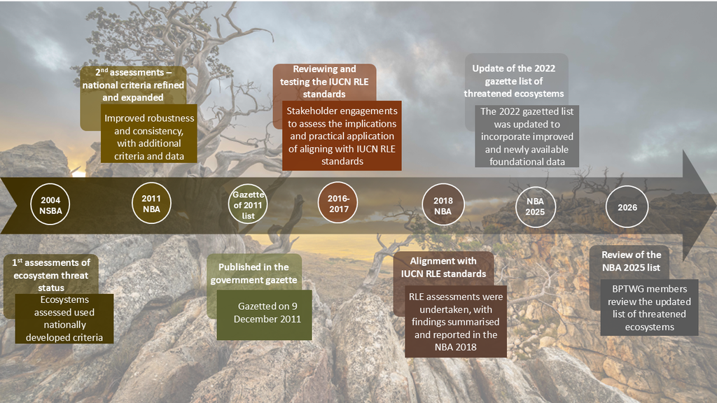

Figure 1: Timeline of South Africa’s ecosystem threat status assessments, from the first national assessment (2004 NSBA) to the review of the NBA 2025 list of threatened ecosystems by the Biodiversity Planning Technical Working Group (BPTWG). (Image: © Jem Shelton; schematic: Maphale Monyeki)

While the [NBA 2025](https://nba.sanbi.org.za/) represents the fourth reporting on the state of the country’s biodiversity, it also represents the second update of the RLE indicator, incorporating an improved terrestrial ecosystem map, land cover, and invasive alien plant species data. With each iteration of the NBA, the RLE indicator is updated using the most current data available to reflect the present state of terrestrial ecosystems. Changes in threat status between iterations can signal genuine spatial decline driven by new or intensifying threats, they may also result from improvements to the underlying input data. A key example is the terrestrial ecosystem map, which is refined with each NBA iteration as new field evidence, improved mapping tools, and a better understanding of plant community distributions, biodiversity patterns, and ecological dynamics become available. These refinements can lead to minor or major increases or decreases in ecosystem extent, and may result in the introduction of new ecosystem types or supersede the existing ones. In the current assessment, eight new ecosystem types were introduced and the Blombos Strandveld ecosystem was replaced by newly delineated types informed by local contributor data. While these ongoing improvements bring the map progressively closer to an accurate representation of historical ecosystem extents, they also influence threat status, particularly for ecosystems assessed under IUCN RLE Criterion A (Reduction in geographic distribution) and Criterion B (Restricted geographic distribution) (Dayaram et al. 2026 in prep).

[figure not shown]

NBA reports iterations (2004, 2011, 2018 and 2025 versions)

**Here, we provide a summary of ecosystem status changes across the following:**

- Number and area of terrestrial ecosystem types by threat status change class (uplisted, downlisted, unchanged, or newly assessed) between the 2022 gazetted list and the NBA 2025 list
- Biome-level breakdown of status changes across ecosystem types
- Cross-tabulation of ecosystem threat status between the two lists
- The IUCN RLE criteria driving current threat status classifications

## Ecosystem status change summary

A total of 456 ecosystem types were formally recognised in the NBA 2018 assessment, with 120 of these ecosystems classified as threatened and subsequently gazetted in 2022. Since then, one of these ecosystem types (Blombos Strandveld) was replaced, and eight new ecosystem types were introduced in the updated terrestrial ecosystem map published in 2024, bringing the total to 463 ecosystem types. Of South Africa’s historical terrestrial extent (1,218,453 km²), approximately 81% (980,959 km²) is currently remaining in a natural state (Table 1).

The threat status of the vast majority of terrestrial ecosystem types (n = 434) remained unchanged between the 2022 gazetted list and the NBA 2025 list of threatened ecosystems.

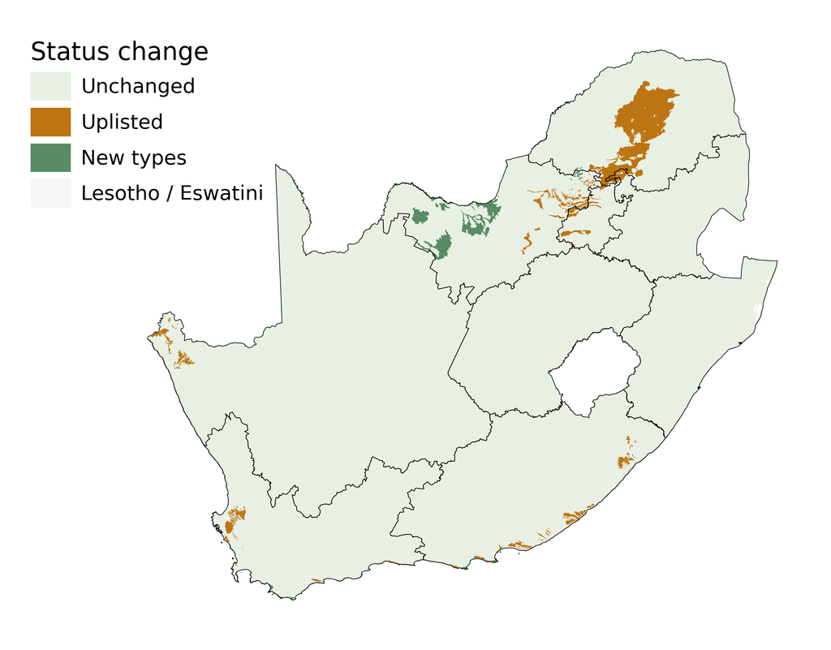

Figure 2: Ecosystem threat status change map

## Land cover data release lag

Land cover data is supplied by the Department of Forestry, Fisheries and Environment (DFFE) approximately two to three years after the date of the satellite imagery. For example, the 2022 National Land Cover dataset was released by DFFE in late 2024. This means that for the 2025 RLE assessment we used the 2022 land cover dataset, while the 2022 RLE gazette was based on the 2018 land cover dataset.

These ecosystem types account for 1,178,035 km² (79%) of South Africa’s historical terrestrial extent, of which 957,637 km² (98%) represents the natural habitat currently remaining in South Africa. Despite this overall stability in threat status, ongoing habitat loss and degradation, together with refinements to the terrestrial ecosystem map, resulted in changes to the threat status for a small number of ecosystem types. A total of 21 ecosystem types (4.5% of the 463 recognised types) experienced a further decline in spatial extent, ecological integrity, and/or condition, moving them closer to a state of collapse. These ecosystem types account for 31,212 km² of South Africa’s historical terrestrial extent, of which 17,687 km² of natural habitat remains. This is equivalent to 1% of the total terrestrial landmass and 2% of all natural habitat currently remaining.

The remaining eight ecosystem types (2% of the 463 recognised types) were newly delineated in the updated 2024 terrestrial ecosystem map and therefore have no previous threat status against which change can be assessed. Together, they account for 9,206.3 km² (0.5%) of historical extent and 5,635 km² (1%) of all natural habitat currently remaining in the country (Table 1).

Table 1: The number and area of ecosystem types by Red List category transition (uplisted, unchanged, or newly delineated) between the 2022 gazetted list and the NBA 2025 list of threatened ecosystems.

| Status Change | Ecosystems Number of ecosystem types | Extent Total historical extent (km²) | Extent Natural extent remaining within South Africa in 2025 (km²) | Remaining habitat % of historical extent remaining as natural habitat | Remaining habitat % of remaining natural habitat in South Africa |
| --- | --- | --- | --- | --- | --- |
| Unchanged | 434 | 1,178,035 | 957,637 | 79% | 98% |
| Uplisted | 21 | 31,212 | 17,687 | 1% | 2% |
| New types | 8 | 9,206 | 5,635 | 0% | 1% |
| Total | 463 | 1,218,454 | 980,959 | 81% | 100% |

## Changes in terrestrial ecosystem threat status: 2022 gazetted list vs NBA 2025

Table 2 lists every ecosystem type that were listed as threatened on the NBA 2025 RLE assessments and shows what their threat status as published in the Government Gazette (Gazette Number 47526, Notice Number 2747), the transition between them, and its status change. Types that were newly delineated in the 2024 terrestrial ecosystem map are included where they were assessed as threatened. The sections below break these changes down by biome and by category transition.

Table 2: Threatened ecosystem types that retained their threat status, were uplisted, or were newly identified as threatened in the NBA 2025 assessment, compared with the 2022 gazetted list.

| <sup>[ⓘ](https://itables.org/fallbacks/static_preview.html)</sup>Name | Biome | RLE 2022 | RLE 2025 | RLE 2022–2025 | Status change |
| --- | --- | --- | --- | --- | --- |
| Gauteng Shale Mountain Bushveld | 🌳Savanna | LC | EN | LC→EN | Uplisted |
| Goukamma Dune Thicket | ●Albany Thicket | LC | CR | LC→CR | Uplisted |
| Hopefield Sand Fynbos | 🌿Fynbos | LC | EN | LC→EN | Uplisted |
| Makhado Sweet Bushveld | 🌳Savanna | LC | EN | LC→EN | Uplisted |
| Moot Plains Bushveld | 🌳Savanna | LC | EN | LC→EN | Uplisted |
| Ngongoni Veld | 🌳Savanna | VU | EN | VU→EN | Uplisted |
| Norite Koppies Bushveld | 🌳Savanna | LC | EN | LC→EN | Uplisted |
| Northern Richtersveld Scorpionstailveld | 🌵Succulent Karoo | LC | EN | LC→EN | Uplisted |
| Peninsula Shale Fynbos | 🌿Fynbos | VU | CR | VU→CR | Uplisted |
| Piketberg Sandstone Fynbos | 🌿Fynbos | LC | CR | LC→CR | Uplisted |
| Polokwane Plateau Bushveld | 🌳Savanna | LC | EN | LC→EN | Uplisted |
| Potberg Sandstone Fynbos | 🌿Fynbos | LC | CR | LC→CR | Uplisted |
| Sardinia Forest Thicket | ●Albany Thicket | LC | CR | LC→CR | Uplisted |
| South Eastern Coastal Thornveld | 🌳Savanna | LC | EN | LC→EN | Uplisted |
| Southern Cape Dune Fynbos | 🌿Fynbos | LC | CR | LC→CR | Uplisted |
| Southern Richtersveld Scorpionstailveld | 🌵Succulent Karoo | LC | CR | LC→CR | Uplisted |
| Springbokvlakte Thornveld | 🌳Savanna | VU | EN | VU→EN | Uplisted |
| St Francis Dune Thicket | ●Albany Thicket | LC | EN | LC→EN | Uplisted |
| Swartland Alluvium Renosterveld | 🌿Fynbos | VU | CR | VU→CR | Uplisted |
| Upper Annisvlakte Succulent Shrubland | 🌵Succulent Karoo | LC | CR | LC→CR | Uplisted |
| Western Gariep Lowland Desert | 🏜Desert | LC | CR | LC→CR | Uplisted |
| Grootbos Strandveld | 🌿Fynbos | Not Evaluated | CR | Not Evaluated→CR | New type |
| Southeastern Strandveld | 🌿Fynbos | Not Evaluated | EN | Not Evaluated→EN | New type |
| Southwestern Strandveld | 🌿Fynbos | Not Evaluated | EN | Not Evaluated→EN | New type |
| St Franscis Strandveld | 🌿Fynbos | Not Evaluated | CR | Not Evaluated→CR | New type |
| Agulhas Limestone Fynbos | 🌿Fynbos | CR | CR | CR↔CR | Unchanged |
| Agulhas Sand Fynbos | 🌿Fynbos | CR | CR | CR↔CR | Unchanged |
| Albany Alluvial Vegetation | 〰Azonal Vegetation | EN | EN | EN↔EN | Unchanged |
| Albertinia Sand Fynbos | 🌿Fynbos | EN | EN | EN↔EN | Unchanged |
| Alexander Bay Coastal Duneveld | 🏜Desert | CR | CR | CR↔CR | Unchanged |

[output cut: 111 more lines]

**ImportantReview the revised threatened list**

**BPTWG stakeholders are invited to review the [revised list](https://docs.google.com/spreadsheets/d/1Sm2SlZ7UgGlqnOoaGKtv2S9DMFC8SCeGEenoJv6--XI/edit?usp=sharing) and provide comments and recommendations directly in the sheet. Stakeholders are also encouraged to flag any additional data they have access to that could inform the current revision of the 2025 list and future updates.**

### Number of ecosystem types per biome and status change

Ecosystem pressures are unevenly spread across the landscape, with some biomes under more pressure than others. Equally, efforts to improve the baseline data that inform the RLE assessments are uneven across the landscape. Various factors can be attributed to this, including differing conservation priorities, uneven distribution of funding and technical capacity, available expertise, and stakeholder involvement, among others. These factors also influence the iterative update of South Africa’s terrestrial ecosystem map, with different regions of the map updated with each iteration. Oftentimes, the refinements occur at different scales depending on the source data used for refinement, and some regions of the map have remained unchanged since 2006.

Of all biomes and azonal areas, Fynbos and Savanna have the highest counts of ecosystem types that have further deteriorated in condition and/or declined in extent since the previous assessment, moving them closer to a collapsed state (n = 6 and n = 8 respectively, equivalent to 5% and 9% of each biome’s own total ecosystem types). The threat status of all ecosystem types within five of the biomes and regions (i.e., Grassland, Azonal Vegetation, Nama-Karoo, Forests, and Indian Ocean Coastal Belt) remained unchanged between the 2018 and 2025 RLE assessment periods (Figure 3). This stability may comparatively reflect a lower rate of worsening pressure on the remaining natural habitat and condition of ecosystems within these biomes. It could also partly reflect more limited data availability or fewer mapping updates in these areas.

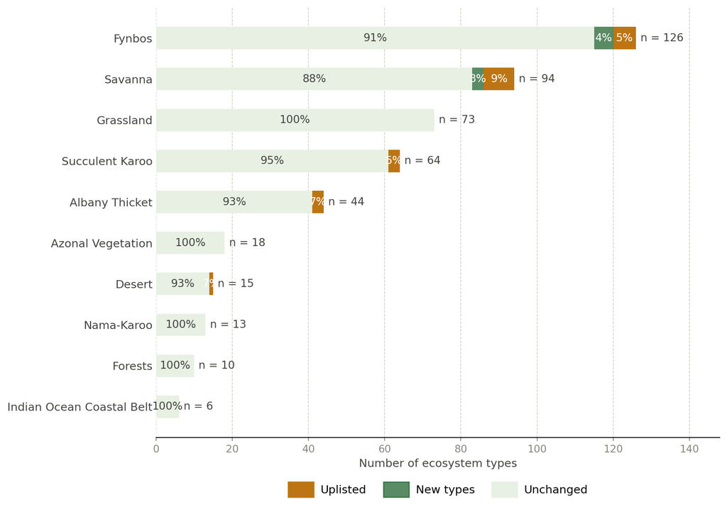

Figure 3: Number of ecosystem types by biome and status change between the 2022 gazetted list and the NBA 2025 list of threatened ecosystems.

### Transition matrix

A transition matrix was used to quantify transitions in ecosystem threat status between the 2022 gazetted list of threatened ecosystems and the NBA 2025 list of threatened ecosystems (Figure 4). The diagonal cells represent ecosystem types whose threat status remained unchanged between the two lists, while cells above the diagonal represent downlisted ecosystem types (i.e. ecosystems whose threat status improved) and cells below the diagonal represent uplisted ecosystem types (i.e. ecosystems whose threat status worsened).

No assessed ecosystem types were downlisted between the 2022 gazetted list and the 2025 NBA list of threatened ecosystems. However, 21 ecosystem types were uplisted. Of these, ten were reclassified as Critically Endangered, comprising eight ecosystem types previously classified as Least Concern and two previously classified as Vulnerable. The remaining 11 ecosystem types were uplisted to Endangered, including nine from Least Concern and two from Vulnerable.

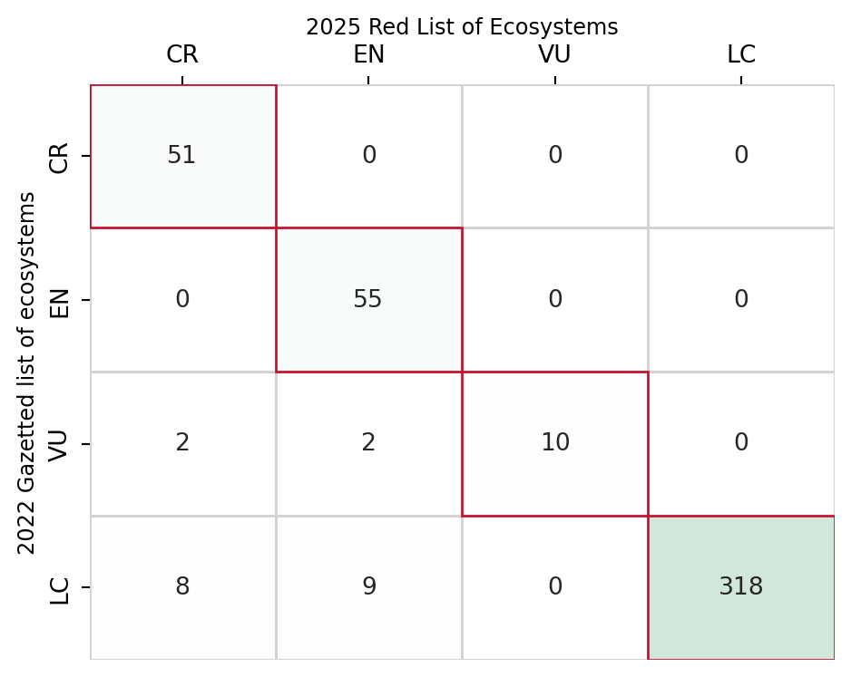

Figure 4: 2022 gazetted list of ecosystems vs NBA 2025 list of threatened ecosystems

## Criteria triggered

By examining the [IUCN RLE criteria](https://portals.iucn.org/library/sites/library/files/documents/2024-021-En.pdf) under which ecosystems were listed as threatened, it is possible to identify the key processes contributing to ecosystem collapse risk. Table 3 summarises the criteria, and combinations of criteria, under which South Africa’s threatened terrestrial ecosystems were listed. In practical terms, these criteria reflect whether ecosystems are threatened because they have lost large areas of their natural habitat, have restricted distributions and continue to decline, have experienced abiotic degradation, or because their ecological functioning has been disrupted by pressures such as invasive alien plants, altered fire regimes and/or overgrazing.

Threatened ecosystems were listed under different RLE criteria and, in some cases, under multiple criteria. This indicates that for some ecosystems, a single dominant threatening process was sufficient to elevate risk of collapse, whereas for others multiple interacting pressures have reduced ecosystem extent and/or degraded ecological condition. Of the five RLE criteria, only three (Criteria A, B and D) were applied in this iteration of the RLE assessments, owing to data limitations for Criteria C and E. Despite being unable to apply the full range of sub-criteria within each criterion, the criteria that were applied provide a clear picture of the main processes driving the risk of collapse and of ecosystems that are inherently more vulnerable because of their limited distribution.

Most threatened terrestrial ecosystem types in South Africa were listed under Criterion B, either alone or in combination with Criterion A. Criterion B identifies ecosystems with restricted distributions that are also experiencing continuing decline in extent or condition. In total, 116 of the 141 threatened ecosystem types were listed under Criterion B as the sole basis for their listing. This is not unexpected, as terrestrial ecosystem types are delineated at the fine thematic resolution of vegetation types in the National Vegetation Map. Many therefore have limited mapped extents relative to the distribution thresholds applied under Criterion B.

The majority (n = 78) of the 116 types were listed under Criterion B for having a restricted extent with ongoing spatial decline, indicating that many ecosystems continue to lose natural habitat due to anthropogenic pressures. These include cultivation, plantation forestry, mining, urban and industrial expansion, infrastructure development, and other forms of land-cover transformation that reduce and fragment remaining natural habitat. A further 20 ecosystem types were listed for having a restricted extent with ongoing functional decline, and 18 ecosystem types for having a restricted extent with both ongoing spatial and functional decline (Table 3). These patterns suggest that, in addition to habitat loss and fragmentation, many ecosystems are being degraded by pressures such as invasive alien plants, altered fire regimes and erosion, which reduce ecological condition even where natural cover persists. Although the range of potential degrading pressures is broad, only those for which sufficient data were available were considered in this assessment.

Criterion A was less frequently the sole basis for listing, but remains an important indicator of ecosystems that have undergone substantial historical reduction in extent. Eight ecosystem types were listed under Criterion A alone, while a further 15 were listed under combinations of Criteria A and B. These combinations indicate ecosystems that have already experienced major historical habitat loss and whose remaining natural areas are both restricted in extent and still under pressure (Table 3).

Only two ecosystem types were listed under Criterion D for biotic disruption, indicating that this process alone was seldom sufficient to trigger a threatened listing in this assessment. Overall, the pattern of criteria triggered suggests that the risk of collapse for South Africa’s threatened terrestrial ecosystems is influenced primarily by the interaction between restricted distribution, ongoing habitat loss and fragmentation, and declining ecological condition. It should be noted, however, that South Africa lacks a wall-to-wall map of ecosystem condition and integrity, which limits comprehensive application of the sub-criteria under Criteria C and D. This partly explains why few ecosystem types were listed as threatened on the basis of degrading pressures alone. These data limitations are well acknowledged in South Africa, and efforts to address some of these gaps are underway through focused research led by SANBI through the [Southern Africa: spatial biodiversity assessment, prioritisation and planning (SBAPP)](https://www.sanbi.org/biodiversity/building-knowledge/biodiversity-monitoring-assessment/the-sbapp-regional-project/) project. This project aims to develop a national database that is fit for the purpose of ecosystem and species redlisting assessments.

Table 3: Ecosystem threat combinations by RLE 2025 categories

| Symptoms of ecosystem decline by RLE criteria triggered | Red List of Ecosystems 2025 CR | Red List of Ecosystems 2025 EN | Red List of Ecosystems 2025 VU | **Total** |  |
| --- | --- | --- | --- | --- | --- |
| Criteria A & B |  |  |  |  |  |
| Habitat loss that occurred historically and is ongoing | █ (2) | █ (2) | █ (4) |  | 8 |
| Habitat loss that occurred historically and is ongoing, and a decline in ecosystem functioning | █ (3) | █ (4) |  | 7 |  |
| Criterion A |  |  |  |  |  |
| Historical habitat loss | █ (2) | █ (3) | █ (3) | 8 |  |
| Criterion B |  |  |  |  |  |
| Ongoing decline in ecosystem functioning | ██ (12) | █ (8) |  | 20 |  |
| Ongoing habitat loss | █████ (35) | ██████ (41) | █ (2) | 78 |  |
| Ongoing habitat loss and decline in ecosystem functioning | █ (9) | █ (9) |  | 18 |  |
| Criterion D |  |  |  |  |  |
| Disruption of biotic processes through altered ecological interactions |  | █ (1) | █ (1) | 2 |  |

Historical reference date: 1750, in line with IUCN Red List of Ecosystems Guidelines (IUCN 2024) **Sub-criteria applied under each criterion:** Criterion A (Reduction in geographic distribution) → A2b & A3 Criterion B (Restricted geographic distribution) → B1ia, B2ia, B1iiia & B2iiia Criterion D (Disruption of biotic processes) → D1 & D3